# Practice 12

Elena Tuzhilina

April 4, 2023

### Question 1

You are given information about 15 Titanic passengers.

|  | PassengerId | Sex | Age | Class | Survived |
| --- | --- | --- | --- | --- | --- |
| 773 | 773 | female | 57 | 2 | no |
| 698 | 698 | female | NA | 3 | yes |
| 652 | 652 | female | 18 | 2 | yes |
| 548 | 548 | male | NA | 2 | yes |
| 890 | 890 | male | 26 | 1 | yes |
| 875 | 875 | female | 28 | 2 | yes |
| 392 | 392 | male | 21 | 3 | yes |
| 788 | 788 | male | 8 | 3 | no |
| 330 | 330 | female | 16 | 1 | yes |
| 183 | 183 | male | 9 | 3 | no |
| 680 | 680 | male | 36 | 1 | yes |
| 560 | 560 | female | 36 | 3 | yes |
| 104 | 104 | male | 33 | 3 | no |
| 136 | 136 | male | 23 | 2 | no |
| 37 | 37 | male | NA | 3 | yes |

1. Compute the contingency table for Sex and Class variables.
2. Compute marginal frequencies for Sex and Class variables.
3. Compute joint probabilities for P(Sex = …, Class = …). Six probabilities in total.
4. Compute joint probabilities for P(Class = …|Sex = …). Six probabilities in total.
5. Draw a stacked barplot. Do you think there is an association between these two variables?

### Question 2

You are given Sex vs Class contingency table for all Titanic passengers, and you want to test these two variables for the independence.

```r
tab = table(data$Class, data$Sex)
kable(tab)
```

| female | male |
| --- | --- |
| 94 | 122 |
| 76 | 108 |
| 144 | 347 |

1. State $H_0$ and $H_a$.
2. Find expected and observed counts for this table.
3. Find the test statistic.
4. Find the p-value.
5. Draw the conclusion at significance level $0.01$.

# Question 3

The iris data set gives the measurements in centimeters of the variables sepal length and width and petal length and width, respectively, for 50 flowers from each of 3 species of iris (150 flowers in total). The species are Iris setosa, versicolor, and virginica.

Here are summary statistics for Sepal and Petal lengths.

```r
mean(Sepal.Length)
```

```
## [1] 5.843333
```

```r
mean(Petal.Length)
```

```
## [1] 3.758
```

```r
sd(Sepal.Length)
```

```
## [1] 0.8280661
```

```r
sd(Petal.Length)
```

```
## [1] 1.765298
```

```r
cor(Sepal.Length, Petal.Length)
```

```
## [1] 0.8717538
```

1. Do you think there is an association between Sepal and Petal lengths?
2. You want to fit the regression line to the following scatterplot plot.

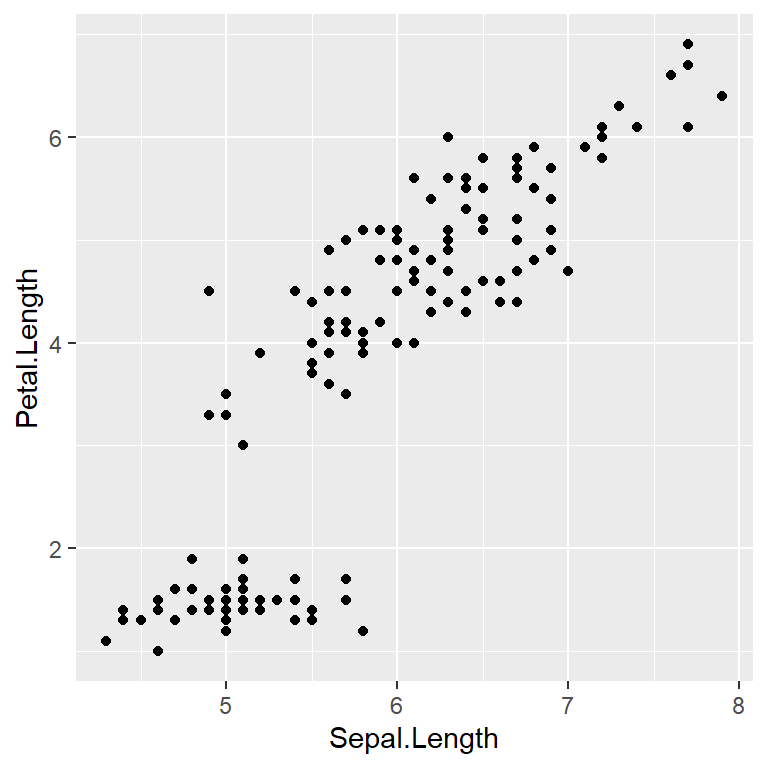

State the regression line equation.

3. Find regression coefficients.
4. What is the interpretation of the regression coefficients?
5. Check if point $Sepal.Length = 6$ and $Petal.Length = 3$ lies on the regression line.
6. Find the residual for point $Sepal.Length = 6$ and $Petal.Length = 3$. Does this point lie below or above the regression line?
7. Check that $Sepal.Length = \bar{x}$ and $Petal.Length = \bar{y}$ point lies on the regression line.
8. Use the regression line to predict the value of Petal length if Sepal length is $6$ and $7$.
9. Add the regression line to the scatterplot.
10. Find $TSS$ from the provided information.
11. Find $R^2$ from the provided information. Do you think linear model fits the data well?
12. Find $RSS$ from the provided information.
13. Find $ESS$ from the provided information.